# Moodle Tasks

## Задача 1

Хвърлят се $30$ зара.

```r
> dice <- sample(x = 1:6, size = 30, replace = TRUE); dice
 [1] 4 6 5 2 5 3 4 6 5 3 1 2 1 3 5 5 6 6 2 5 2 3 1 5 2 3 1 3 6 2
```

Оценете вероятността да се паднат по-малко от $5$ шестици?
$$X \in Bi(30, \frac{1}{6})$$

```r
> x <- rbinom(1000, 30, 1/6)
> sum(x <= 4) / length(x)
[1] 0.418
```

Каква е вероятността да се паднат по-малко от $5$ шестици?
$$P(X < 5) = P(X <= 4)$$

```r
> pbinom(q = 4 , size = 30, prob = 1/6)
[1] 0.4243389
```

Сравнете теоретичната вероятност с експериментални данни. Виждаме, че при $1000$ опита числата са много близки.

Oт **закона за големите числа (ЗГЧ)** - при увеличаване на броя на опитите оценката се приближава все повече до оценявания параметър. В случая относителната честота на опитите, при които имаме по-малко от $5$ шестици все повече се приближава до вероятността на събитието да имаме по-малко от $5$ шестици.

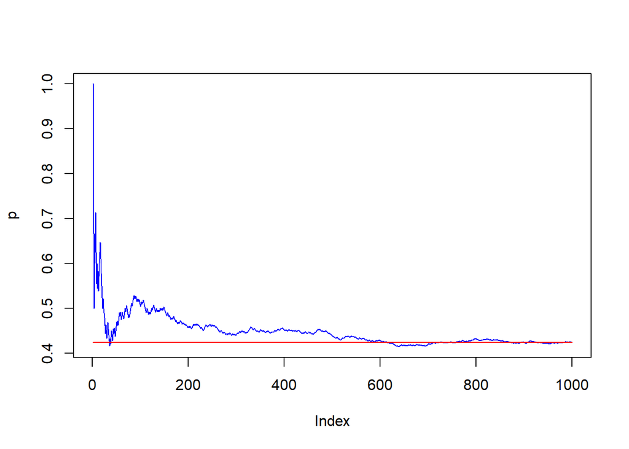

```r
> numberOfSixes <- rbinom(n = 1000, size = 30 , prob = 1/6)
> head(numberOfSixes, n = 10)
 [1] 3 3 6 7 3 3 2 5 5 3
> p <- cumsum(numberOfSixes < 5) / (1:1000)
> head(p, n = 10)
 [1] 1.0000000 1.0000000 0.6666667 0.5000000 0.6000000 0.6666667 0.7142857
 [8] 0.6250000 0.5555556 0.6000000
> plot(p, type = "l", col = "blue")
> expected <- pbinom(4, size = 30, prob = 1/6); expected
[1] 0.4243389
> lines(rep(expected, 1000), col = "red")
```

Можем да твърдим, че с вероятност $0.75$ ще се паднат повече от максимално колко шестици?
$$max\{x \in 0 \cup \mathbb N : P(X > x) \geq 0.75\}$$

```r
> qbinom(p = 0.75, size = 30, prob = 1/6, lower.tail = FALSE)
[1] 4
```

## Задача 2

Стрелец уцелва мишена с вероятност $0.2$. За да спечели стрелецът трябва да направи три точни попадения. Каква е вероятноста за това да са му необходими:
$$X \in NegBi(n = 3,\ p = 0.2)$$
а) точно $8$ изстрела;
$$P(X = 8 - 3) = P(x = 5) = P(X <= 5) - P(X <= 4)$$

```r
> dnbinom(5, size = 3, prob = 0.2)
[1] 0.05505024
> pnbinom(5, size = 3, prob = 0.2) - pnbinom(4, size = 3, prob = 0.2)
[1] 0.05505024
```

б) повече от $6$ изстрела;
$$P(X > 6 - 3) = P(X > 3)$$

```r
> pnbinom(3 , size = 3, prob = 0.2, lower.tail = FALSE)
[1] 0.90112
```

в) между $5$ и $8$ изстрела, включително?
$$P(5 - 3 <= X <= 8 - 3) = P(2 <= X <= 5) = P(X <= 5) - P(X <= 1)$$

```r
> pnbinom(5 , size = 3, prob = 0.2) - pnbinom(1 , size = 3, prob = 0.2)
[1] 0.1758822
```

## Задача 3

В урна има $7$ бели и $6$ черни топки. От урната последователно без връщане се теглят $8$ топки. Нека X е броя на изтеглените бели. Направете $1000$ симулации.

Без връщане => имаме зависими опити
$$X \in HG(m = 7, n = 6, k = 8)$$
където,

$m$ - броя на белите топки в урната

$n$ - броя на черните топки в урната

$k$ - броя на топките изтеглени от урната

```r
> m <- 7; n <- 6; k <- 8
> x <- rhyper(1000, m, n, k)
```

По симулациите пресметнете границите, в който се намира $X$.

```r
> range(x)
[1] 2 7
```

Оценете $EX$ и $DX$.

```r
> mean(x)
[1] 4.276
> var(x)
[1] 0.7786026
```

Намерете теоретичните стойности за $EX$ и $DX$.
$$\mu = E[X] = k \frac{m}{m+n} = 8 \frac{7}{7 + 6} = \frac{56}{13} \approx 4.3077$$
$$\sigma^2 = D[X] = \frac{kmn(m+n-k)}{(m+n)^2(m+n-1)} = \frac{8 * 7 * 6 * (7 + 6 - 8)}{(7 + 6)^2 (7 + 6 - 1)} =$$
$$= \frac{140}{169} \approx 0.8284$$

Представете графично емперичното и теоритичното разпределение на $X$(на една графика).

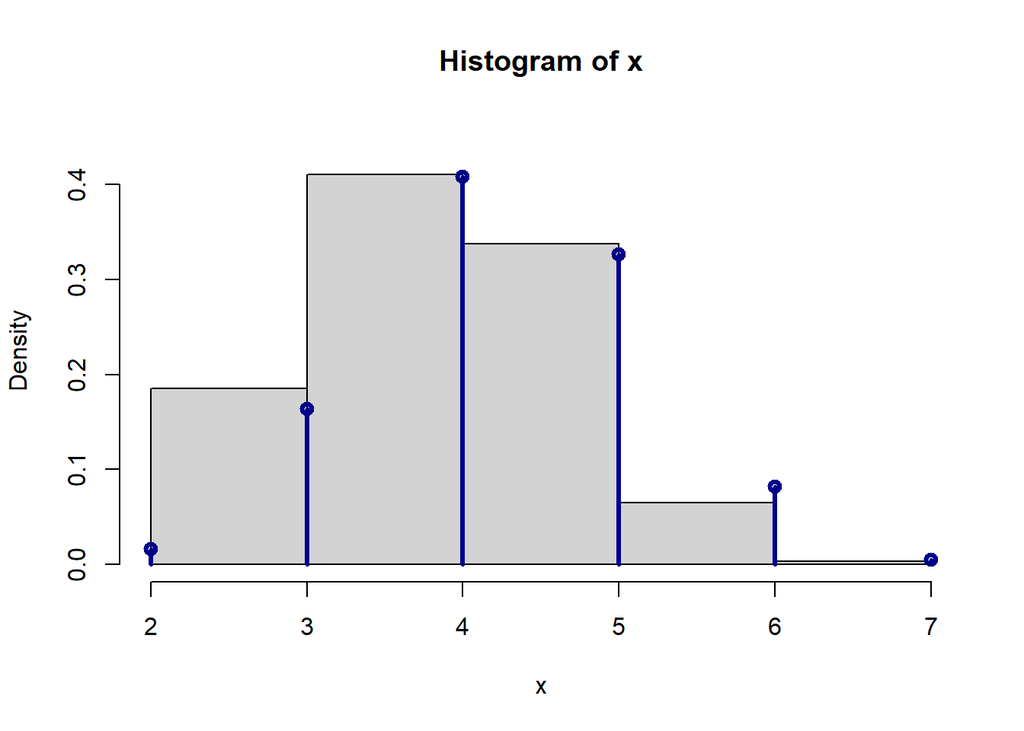

```r
> hist(x,
+      breaks = max(0, k-n):min(k, m),
+      probability = TRUE,
+      ylim = c(0, 0.45))
> points(2:7, dhyper(2:7, m, n, k), type = "h", lwd = 3, col = "darkblue")
> points(2:7, dhyper(2:7, m, n, k), type = "p", lwd = 3, col = "darkblue")
```

## Задача 4

Лотария се провежда със следните правила. Всеки участник избира едно число от $1$ до $2n$, не е необходимо да избират различни числа. Когато броят на участлиците снате $n$ се теглят $5$ печеливши числа. Каква е вероятността да се паднат точно две награди. Пресметнет при $n = 10,\ 100,\ 1000,\ 10000$. С каква случайна величина ще моделирате броя на печалбите?

### Решение

Имаме $5$ печеливши и $2n-5$ губещи. От тях теглим $n$ с връщане.
$$X \in Bi(n, \frac{5}{2n})$$
Каква е вероятността да се панат точно $2$ награди е същото като $P(X = 2)$. Тогава за $n = 10, 100, 1000, 10000$ ще имаме

```r
> n <- c(10, 100, 1000, 10000)
> dbinom(2, n, 5 / (2*n))
[1] 0.2815676 0.2587841 0.2567403 0.2565381
```

## Задача 5

Решете задача $4$, ако лицата теглеха различни числа.

### Решение

Имаме $5$ печеливши и $2n-5$ губещи. От тях теглим $n$ без връщане.
$$X \in HG(5, 2n-5, n)$$
Каква е вероятността да се панат точно $2$ награди е същото като $P(X = 2)$. Тогава за $n = 10, 100, 1000, 10000$ ще имаме

```r
> n <- c(10, 100, 1000, 10000)
> dhyper(2, 5, 2*n - 5, n)
[1] 0.3482972 0.3156646 0.3128129 0.3125313
```

## Задача 6

За коледно парти всеки от $n$ ($n = 20$) участници носи по един подарък. Подаръците се номерират и в шапка се слагат номерата от $1$ до $n$. Всеки участник си тегли номер и получава съответния подарък. Напишете функции, които пресмятат:

а) теоретичната вероятност;

б) емперичната вероятност изчислена по $10000$ опита;

никой да не получи свояподарък.

### Решение

Нека

$А_1$ е събитието $1$-вия да си е получил подаръка,

$А_2$ е събитието $2$-рия да си е получил подаръка,

…

$А_n$ е събитието $n$-тия да си е получил подаръка.

$$P(\bar{A_1} \cap \bar{A_2} \cap ... \cap \bar{A_n}) = 1 - P(A_1 \cup A_2 \cup ... \cup A_n) =$$

$$= 1 - \sum_{l = 1}^{n}{(-1)^{l+1} \sum_{1 \leq i_1 < ... < i_l \leq n} P(A_{i_1} ... A_{i_l}) } =$$
$$= 1 - \sum_{l = 1}^{n}{(-1)^{l+1} \sum_{1 \leq i_1 < ... < i_l \leq n}{\frac{1^l(n-l)!}{n!}} } =$$
$$= 1 - \sum_{l = 1}^{n}{(-1)^{l+1} {n \choose l} \frac{(n-l)!}{n!}} =$$
$$= 1 - \sum_{l = 1}^{n}{(-1)^{l+1} \frac{n!}{l!(n-l)!} \frac{(n-l)!}{n!}} =$$
$$= 1 - \sum_{l = 1}^{n}{\frac{(-1)^{l+1}}{l!}} = 1 + \sum_{l = 1}^{n}{\frac{(-1)^{l}}{l!}} =$$
$$= \sum_{l = 0}^{n}{\frac{(-1)^{l}}{l!}} = \sum_{l = 0}^{20}{\frac{(-1)^{l}}{l!}} = 0.3679$$
Сега да симулираме $10 000$ пъти пермутациите на числата $1,...,20$

```r
> library(pracma)
Warning: package 'pracma' was built under R version 4.0.3
> presentPermut <- replicate(10000, randperm(1:20, 20))
```

Сега да преброим в колко от тях нито един индекс не съвпада с числото

```r
> a <- 0
> for (i in 1:10000) {
+   a[i] <- sum(presentPermut[, i] == 1:20) == 0
+ }
> sum(a)
[1] 3674
```

Да сметнем емперичната вероятност и да я сравним с теоретичната получена по-горе.

```r
> sum(a) / 10000
[1] 0.3674
```